# Assignment 3

Briana Flynn

9/24/2020

# Instructions: Correlations, Differences, and Associations

For all possible pairs of variables in your dataset, test the relationship between the two variables. Indicate the significance and (if appropriate) the magnitude of each relationship.

## Variables

1. Household income (continuous) : HINCP
2. Gross monthly rent payment (continuous) : GRNTP
3. Gross rent as a percentage of monthly income (continous) : GRPIP
4. Access to the internet (categorical) : ACCESS
5. Limited English speaking household (categorical) : LNGI
6. Presence and age of children in household (categorical): HUPAC

## Testing the Relationships between All Variables

In order to determine the permutations needed and the appropriate test, I’ve paired all of my variables and noted whether there are continuous (“cont”), categorical with two categories (“cat. 2”), or categorical with three or more categories (“cat. 3+”).

1. HINCP (cont) + GRNTP (cont) : Pearson
2. HINCP (cont) + GRPIP (cont) : Pearson
3. HINCP (cont) + ACCESS (cat. 3+) : ANOVA
4. HINCP (cont) + LNGI (cat. 2) : 2-sample T-test
5. HINCP (cont) + HUPAC (cat. 3+) : ANOVA
6. GRNTP (cont) + GRPIP (cont) : Pearson
7. GRNTP (cont) + ACCESS (cat. 3+) : ANOVA
8. GRNTP (cont) + LNGI (cat. 2) : 2-sample T-test
9. GRNTP (cont) + HUPAC (cat. 3+) : ANOVA
10. GRPIP (cont) + ACCESS (cat. 3+) : ANOVA
11. GRPIP (cont) + LNGI (cat. 2) : 2-sample T-test
12. GRPIP (cont) + HUPAC (cat 3+) : ANOVA
13. ACCESS (cat. 3+) + LNGI (cat. 2) : Chi-square
14. ACCESS (cat. 3+) + HUPAC (cat. 3+) : Chi-square
15. LNGI (cat. 2) + HUPAC (cat. 3+) : Chi-square

```r
households <- read_csv("households.csv")
attach(households)
```

## Relationships between Continuous Variables

```r
correlation <- cor.test(households$HINCP, households$GRNTP)

correlation
```

```
##
##  Pearson's product-moment correlation
##
## data:  households$HINCP and households$GRNTP
## t = 73.211, df = 16496, p-value < 2.2e-16
## alternative hypothesis: true correlation is not equal to 0
## 95 percent confidence interval:
##  0.4836094 0.5066452
## sample estimates:
##       cor
## 0.4952144
```

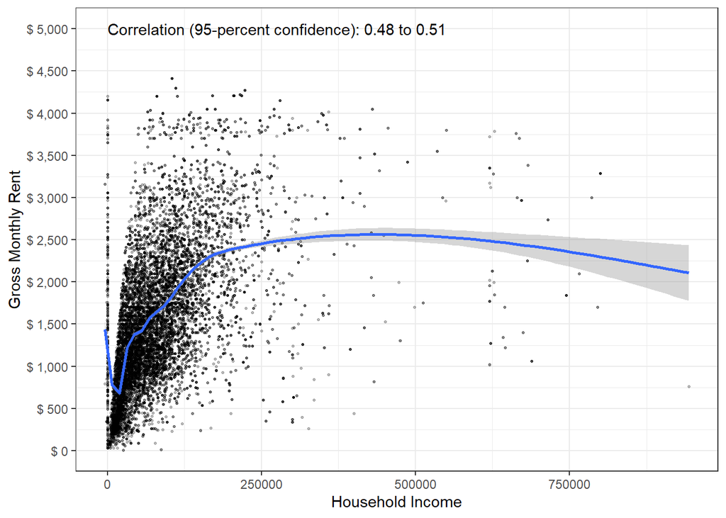

```r
ggplot(households, aes(x = HINCP, y = GRNTP)) +
  geom_point(size = 0.5, alpha = 0.25, position = "jitter") +
  geom_smooth() +
  theme_bw() +
  scale_x_continuous(name = "Household Income") +
  scale_y_continuous(name = "Gross Monthly Rent",
                     breaks = seq(0, 6000, by = 500),
                     labels = paste("$",
                                    prettyNum(seq(0, 6000, by = 500),
                                              big.mark = ","))) +
  annotate(geom = "text", x = 0, y = 5000,
           label = paste("Correlation (95-percent confidence):",
                         prettyNum(correlation$conf.int[1], digits = 2),
                         "to",
                         prettyNum(correlation$conf.int[2], digits = 2)),
           hjust = 0)
```

While there is a statistically significant relationship between Household Income and Rent, the strength of the relationship is not very strong, with a correlation of around 0.5.

```r
correlation <- cor.test(households$HINCP, households$GRPIP)

correlation
```

```
##
##  Pearson's product-moment correlation
##
## data:  households$HINCP and households$GRPIP
## t = -65.447, df = 16496, p-value < 2.2e-16
## alternative hypothesis: true correlation is not equal to 0
## 95 percent confidence interval:
##  -0.4660519 -0.4418229
## sample estimates:
##        cor
## -0.4540213
```

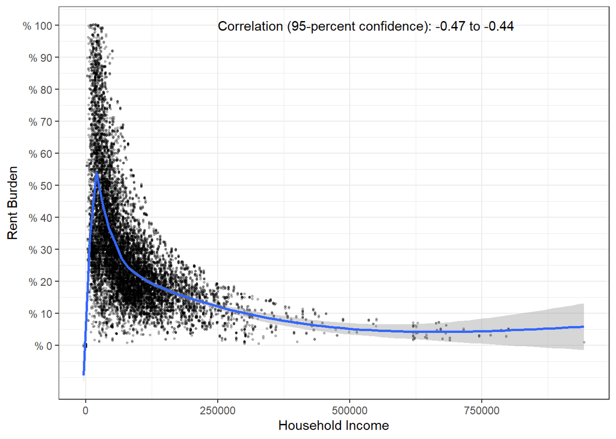

```r
ggplot(households, aes(x = HINCP, y = GRPIP)) +
  geom_point(size = 0.5, alpha = 0.25, position = "jitter") +
  geom_smooth() +
  theme_bw() +
  scale_x_continuous(name = "Household Income") +
  scale_y_continuous(name = "Rent Burden",
                     breaks = seq(0, 100, by = 10),
                     labels = paste("%",
                                    prettyNum(seq(0, 100, by = 10),
                                              big.mark = ","))) +
  annotate(geom = "text", x = 250000, y = 100,
           label = paste("Correlation (95-percent confidence):",
                         prettyNum(correlation$conf.int[1], digits = 2),
                         "to",
                         prettyNum(correlation$conf.int[2], digits = 2)),
           hjust = 0)
```

There is a statistically significant relationship between Household Income and Rent Burden, but not a very strong one, with a correlation of around -0.45.

```r
correlation <- cor.test(households$GRNTP, households$GRPIP)

correlation
```

```
##
##  Pearson's product-moment correlation
##
## data:  households$GRNTP and households$GRPIP
## t = 7.5263, df = 16496, p-value = 5.49e-14
## alternative hypothesis: true correlation is not equal to 0
## 95 percent confidence interval:
##  0.04327788 0.07369232
## sample estimates:
##        cor
## 0.05849868
```

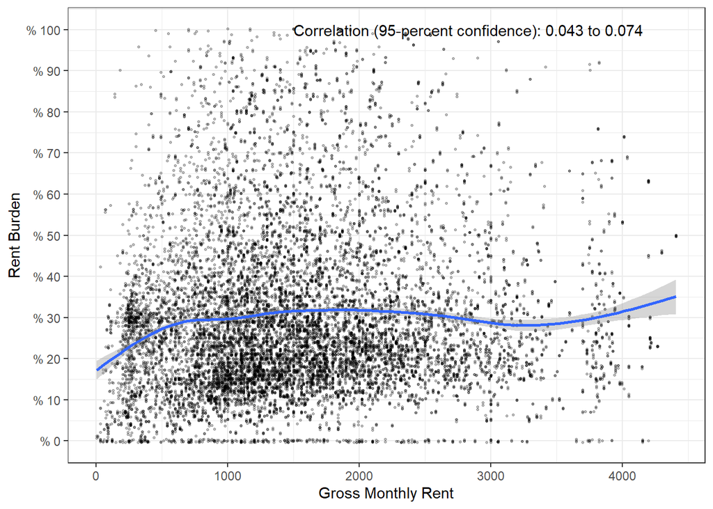

```r
ggplot(households, aes(x = GRNTP, y = GRPIP)) +
  geom_point(size = 0.5, alpha = 0.25, position = "jitter") +
  geom_smooth() +
  theme_bw() +
  scale_x_continuous(name = "Gross Monthly Rent") +
  scale_y_continuous(name = "Rent Burden",
                     breaks = seq(0, 100, by = 10),
                     labels = paste("%",
                                    prettyNum(seq(0, 100, by = 10),
                                              big.mark = ","))) +
  annotate(geom = "text", x = 1500, y = 100,
           label = paste("Correlation (95-percent confidence):",
                         prettyNum(correlation$conf.int[1], digits = 2),
                         "to",
                         prettyNum(correlation$conf.int[2], digits = 2)),
           hjust = 0)
```

Interestingly, there is a very weak relationship between rent and rent burden, with a correlation value of around 0.05. While the P value indicates a significant relationship, the P value is notably higher than in the previous two tests.

## Continous and Categorial Variables

```r
difference = t.test(HINCP ~ LNGI_label == "At least one person in the household 14 and over speaks English only or speaks English 'very well'",
                    data = households)

difference
```

```
##
##  Welch Two Sample t-test
##
## data:  HINCP by LNGI_label == "At least one person in the household 14 and over speaks English only or speaks English 'very well'"
## t = -32.277, df = 3034.2, p-value < 2.2e-16
## alternative hypothesis: true difference in means is not equal to 0
## 95 percent confidence interval:
##  -42962.49 -38041.62
## sample estimates:
## mean in group FALSE  mean in group TRUE
##            46567.24            87069.29
```

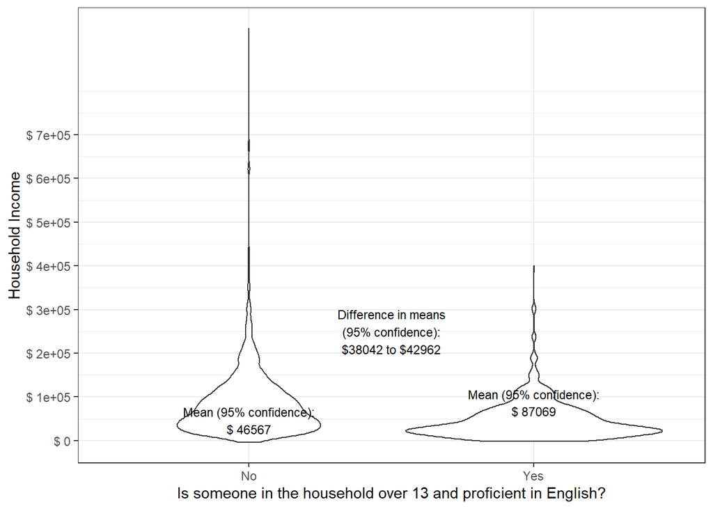

```r
ggplot(households, aes(x = LNGI_label, y = HINCP)) +
  geom_violin() +
  theme_bw() +
  scale_x_discrete(name = "Is someone in the household over 13 and proficient in English?",
                   labels = c("No", "Yes")) +
   scale_y_continuous(name = "Household Income",
                     breaks = seq(0, 750000, by = 100000),
                     labels = paste("$",
                                    prettyNum(seq(0, 750000, by = 100000),
                                              big.mark = ","))) +
  annotate(geom = "text", x = 1.5, y = 250000, size = 3,
           label = paste("Difference in means\n(95% confidence):\n$",
                         prettyNum(abs(difference$conf.int[2]),
                                   digits = 5), " to $",
                         prettyNum(abs(difference$conf.int[1]),
                                   digits = 5),
                         sep = "")) +
  annotate(geom = "text", x = 1, y = difference$estimate[1], size = 3,
           label = paste("Mean (95% confidence):\n$",
                         prettyNum(difference$estimate[1], digits = 5))) +
  annotate(geom = "text", x = 2, y = difference$estimate[2], size = 3,
           label = paste("Mean (95% confidence):\n$",
                         prettyNum(difference$estimate[2], digits = 5)))
```

Here it is clear that there is a significant relationship between Household Income and Household Proficiency in English, with a small P value and close to a 90% ($40,000) difference in average household incomes for whether or not the household is proficient in English.

```r
difference_GRNTP = t.test(GRNTP ~ LNGI_label == "At least one person in the household 14 and over speaks English only or speaks English 'very well'",
                    data = households)

difference_GRNTP
```

```
##
##  Welch Two Sample t-test
##
## data:  GRNTP by LNGI_label == "At least one person in the household 14 and over speaks English only or speaks English 'very well'"
## t = -20.635, df = 2142.5, p-value < 2.2e-16
## alternative hypothesis: true difference in means is not equal to 0
## 95 percent confidence interval:
##  -432.8807 -357.7427
## sample estimates:
## mean in group FALSE  mean in group TRUE
##            1184.837            1580.148
```

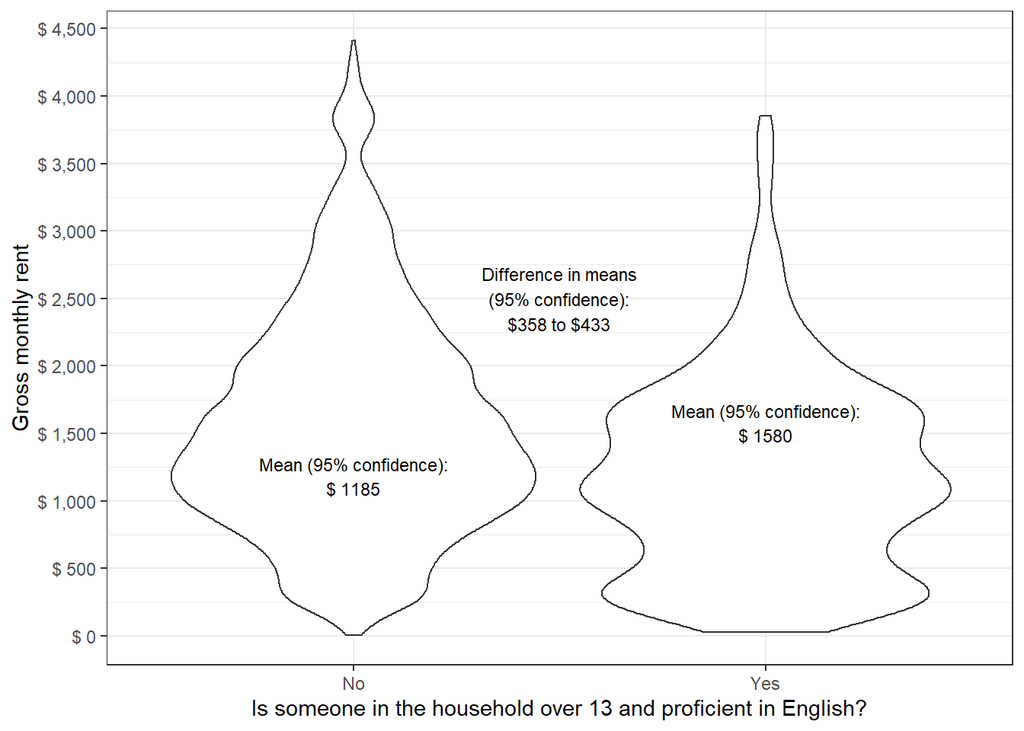

```r
ggplot(households, aes(x = LNGI_label, y = GRNTP)) +
  geom_violin() +
  theme_bw() +
  scale_x_discrete(name = "Is someone in the household over 13 and proficient in English?",
                   labels = c("No", "Yes")) +
   scale_y_continuous(name = "Gross monthly rent",
                     breaks = seq(0, 10000, by = 500),
                     labels = paste("$",
                                    prettyNum(seq(0, 10000, by = 500),
                                              big.mark = ","))) +
  annotate(geom = "text", x = 1.5, y = 2500, size = 3,
           label = paste("Difference in means\n(95% confidence):\n$",
                         prettyNum(abs(difference_GRNTP$conf.int[2]),
                                   digits = 0), " to $",
                         prettyNum(abs(difference_GRNTP$conf.int[1]),
                                   digits = 0),
                         sep = "")) +
  annotate(geom = "text", x = 1, y = difference_GRNTP$estimate[1], size = 3,
           label = paste("Mean (95% confidence):\n$",
                         prettyNum(difference_GRNTP$estimate[1], digits = 4))) +
  annotate(geom = "text", x = 2, y = difference_GRNTP$estimate[2], size = 3,
           label = paste("Mean (95% confidence):\n$",
                         prettyNum(difference_GRNTP$estimate[2], digits = 4)))
```

Here again there appears to be a statistically significant relationship between rent and English proficiency, although at a slightly lower magnitude than household income. The difference between average rents is about $400, with households with English proficiency spending about 30% more on rent than those without English proficiency.

```r
difference_GRPIP = t.test(GRPIP ~ LNGI_label == "At least one person in the household 14 and over speaks English only or speaks English 'very well'",
                    data = households)

difference_GRPIP
```

```
##
##  Welch Two Sample t-test
##
## data:  GRPIP by LNGI_label == "At least one person in the household 14 and over speaks English only or speaks English 'very well'"
## t = 7.1972, df = 1923.7, p-value = 8.773e-13
## alternative hypothesis: true difference in means is not equal to 0
## 95 percent confidence interval:
##  2.921134 5.109425
## sample estimates:
## mean in group FALSE  mean in group TRUE
##            33.59207            29.57679
```

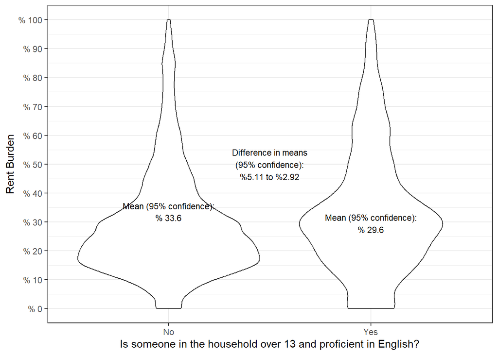

```r
ggplot(households, aes(x = LNGI_label, y = GRPIP)) +
  geom_violin() +
  theme_bw() +
  scale_x_discrete(name = "Is someone in the household over 13 and proficient in English?",
                   labels = c("No", "Yes")) +
   scale_y_continuous(name = "Rent Burden",
                     breaks = seq(0, 100, by = 10),
                     labels = paste("%",
                                    prettyNum(seq(0, 100, by = 10),
                                              big.mark = ","))) +
  annotate(geom = "text", x = 1.5, y = 50, size = 3,
           label = paste("Difference in means\n(95% confidence):\n%",
                         prettyNum(abs(difference_GRPIP$conf.int[2]),
                                   digits = 3), " to %",
                         prettyNum(abs(difference_GRPIP$conf.int[1]),
                                   digits = 3),
                         sep = "")) +
  annotate(geom = "text", x = 1, y = difference_GRPIP$estimate[1], size = 3,
           label = paste("Mean (95% confidence):\n%",
                         prettyNum(difference_GRPIP$estimate[1], digits = 3))) +
  annotate(geom = "text", x = 2, y = difference_GRPIP$estimate[2], size = 3,
           label = paste("Mean (95% confidence):\n%",
                         prettyNum(difference_GRPIP$estimate[2], digits = 3)))
```

There appears to be a significant relationship here again, though the P value is somewhat further from zero than in the previous two variable relationships. There is a relatively small difference in the average rent burden between the two language groups, at around 3 to 5 percent.

```r
anova_HINCPAccess <- aov(HINCP ~ ACCESS_label, data = households)

summary(anova_HINCPAccess)
```

```
##                 Df    Sum Sq   Mean Sq F value Pr(>F)
## ACCESS_label     2 3.080e+12 1.540e+12   263.3 <2e-16 ***
## Residuals    16495 9.647e+13 5.849e+09
## ---
## Signif. codes:  0 '***' 0.001 '**' 0.01 '*' 0.05 '.' 0.1 ' ' 1
```

```r
differences_HINCPAccess <- TukeyHSD(anova_HINCPAccess)

as_tibble(cbind(pair = row.names(differences_HINCPAccess$ACCESS_label),
                differences_HINCPAccess$ACCESS_label))
```

```
## # A tibble: 3 x 5
##   pair                               diff       lwr       upr       `p adj`
##   <chr>                              <chr>      <chr>     <chr>     <chr>
## 1 Yes, by paying a cell phone compa~ 45645.956~ 40757.63~ 50534.27~ 2.677994370~
## 2 Yes, without paying a cell phone ~ 15046.311~ 5033.417~ 25059.20~ 0.001247831~
## 3 Yes, without paying a cell phone ~ -30599.64~ -39586.3~ -21612.8~ 2.677998911~
```

[figure not shown]

```r
ggplot(households, aes(x = ACCESS_label, y = HINCP)) +
  geom_boxplot() +
  theme_bw() +
  theme(axis.text.x = element_text(angle = 90)) +
  scale_x_discrete(name = "Access to Internet") +
  scale_y_continuous(name = "Household Income",
                     breaks = seq(0, 1000000, by = 50000),
                     labels = paste("$",
                                    prettyNum(seq(0, 1000000, by = 50000),
                                              big.mark = ",")))
```

There appears to be a significant relationship between internet access and household income with a P value near 0.

```r
anova_GRNTPAccess <- aov(GRNTP ~ ACCESS_label, data = households)

summary(anova_GRNTPAccess)
```

```
##                 Df    Sum Sq   Mean Sq F value Pr(>F)
## ACCESS_label     2 7.391e+08 369537441   575.6 <2e-16 ***
## Residuals    16495 1.059e+10    642053
## ---
## Signif. codes:  0 '***' 0.001 '**' 0.01 '*' 0.05 '.' 0.1 ' ' 1
```

```r
differences_GRNTPAccess <- TukeyHSD(anova_GRNTPAccess)

as_tibble(cbind(pair = row.names(differences_GRNTPAccess$ACCESS_label),
                differences_GRNTPAccess$ACCESS_label))
```

```
## # A tibble: 3 x 5
##   pair                               diff       lwr       upr       `p adj`
##   <chr>                              <chr>      <chr>     <chr>     <chr>
## 1 Yes, by paying a cell phone compa~ 726.60657~ 675.3890~ 777.8240~ 2.677994370~
## 2 Yes, without paying a cell phone ~ 389.40596~ 284.4955~ 494.3163~ 2.677996857~
## 3 Yes, without paying a cell phone ~ -337.2006~ -431.359~ -243.041~ 2.677997468~
```

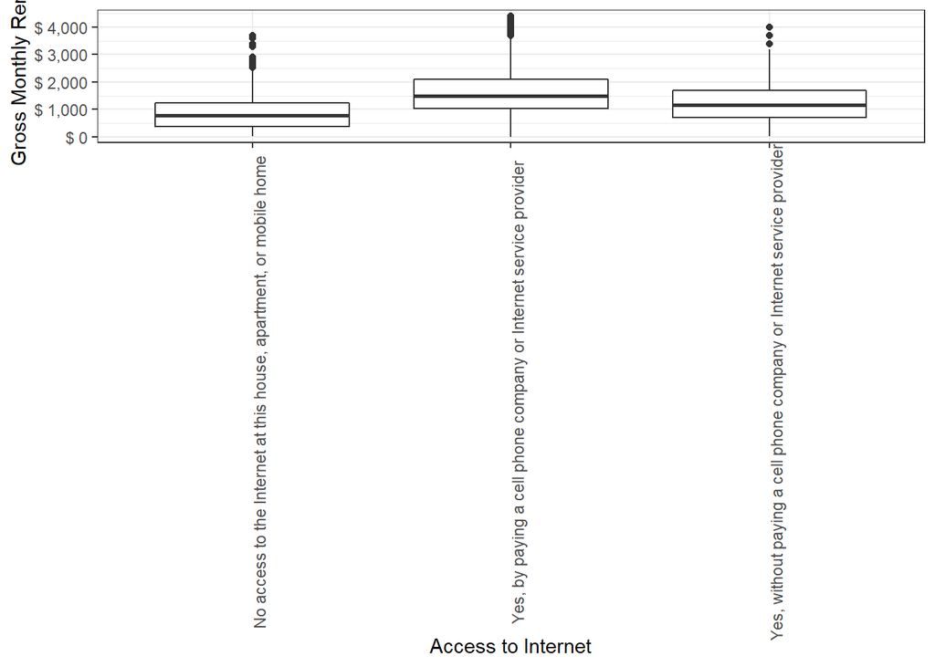

```r
ggplot(households, aes(x = ACCESS_label, y = GRNTP)) +
  geom_boxplot() +
  theme_bw() +
  theme(axis.text.x = element_text(angle = 90)) +
  scale_x_discrete(name = "Access to Internet") +
  scale_y_continuous(name = "Gross Monthly Rent",
                     breaks = seq(0, 6000, by = 1000),
                     labels = paste("$",
                                    prettyNum(seq(0, 6000, by = 1000),
                                              big.mark = ",")))
```

There appears to be a significant relationship between internet access and rent with a P value near 0.

```r
anova_GRPIPAccess <- aov(GRPIP ~ ACCESS_label, data = households)

summary(anova_GRPIPAccess)
```

```
##                 Df  Sum Sq Mean Sq F value Pr(>F)
## ACCESS_label     2   26862   13431   36.43 <2e-16 ***
## Residuals    16495 6081701     369
## ---
## Signif. codes:  0 '***' 0.001 '**' 0.01 '*' 0.05 '.' 0.1 ' ' 1
```

```r
differences_GRPIPAccess <- TukeyHSD(anova_GRPIPAccess)

as_tibble(cbind(pair = row.names(differences_GRPIPAccess$ACCESS_label),
                differences_GRPIPAccess$ACCESS_label))
```

```
## # A tibble: 3 x 5
##   pair                              diff        lwr        upr       `p adj`
##   <chr>                             <chr>       <chr>      <chr>     <chr>
## 1 Yes, by paying a cell phone comp~ -4.0225233~ -5.249876~ -2.79517~ 2.67800116~
## 2 Yes, without paying a cell phone~ -0.0749526~ -2.588977~ 2.439072~ 0.99731131~
## 3 Yes, without paying a cell phone~ 3.94757067~ 1.6911898~ 6.203951~ 0.00012254~
```

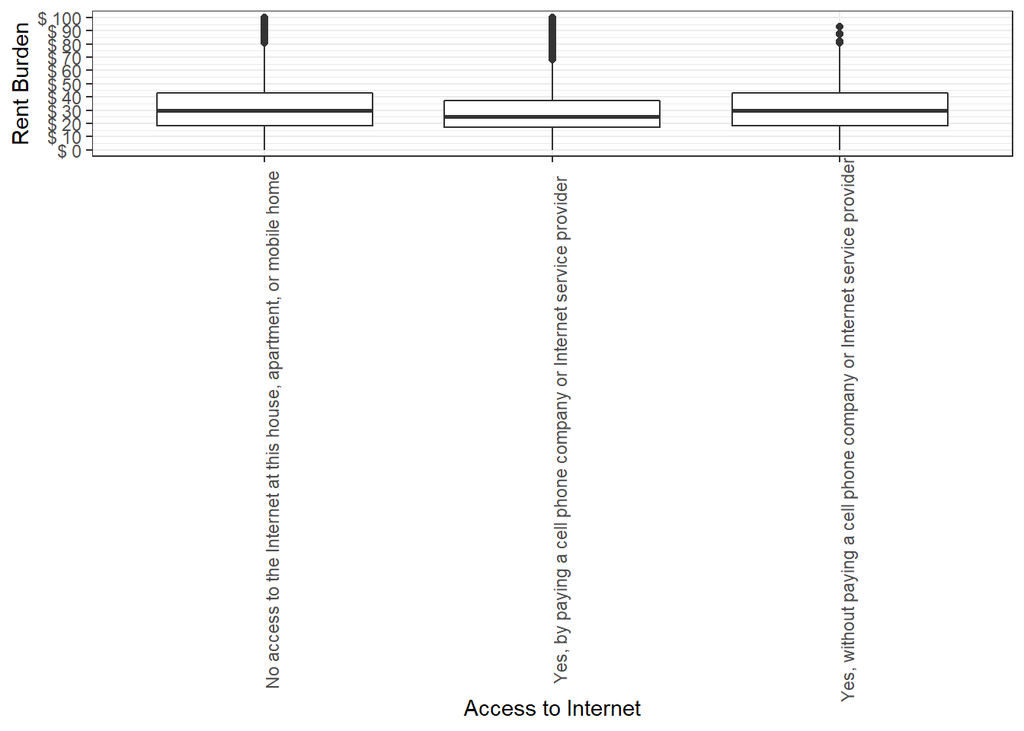

```r
ggplot(households, aes(x = ACCESS_label, y = GRPIP)) +
  geom_boxplot() +
  theme_bw() +
  theme(axis.text.x = element_text(angle = 90)) +
  scale_x_discrete(name = "Access to Internet") +
  scale_y_continuous(name = "Rent Burden",
                     breaks = seq(0, 100, by = 10),
                     labels = paste("$",
                                    prettyNum(seq(0, 100, by = 10),
                                              big.mark = ",")))
```

There appears to be a significant relationship between internet access and rent burden with a P value near 0.

```r
anova_HINCPHUPAC <- aov(HINCP ~ HUPAC_label, data = households)

summary(anova_HINCPHUPAC)
```

```
##                Df    Sum Sq   Mean Sq F value Pr(>F)
## HUPAC_label     3 8.505e+11 2.835e+11   47.38 <2e-16 ***
## Residuals   16494 9.870e+13 5.984e+09
## ---
## Signif. codes:  0 '***' 0.001 '**' 0.01 '*' 0.05 '.' 0.1 ' ' 1
```

```r
differences_HINCPHUPAC <- TukeyHSD(anova_HINCPHUPAC)

as_tibble(cbind(pair = row.names(differences_HINCPHUPAC$HUPAC_label),
                differences_HINCPHUPAC$HUPAC_label))
```

```
## # A tibble: 6 x 5
##   pair                               diff       lwr       upr       `p adj`
##   <chr>                              <chr>      <chr>     <chr>     <chr>
## 1 With children 6 to 17 years only-~ -10816.69~ -14784.2~ -6849.15~ 2.678151211~
## 2 With children under 6 years and 6~ -14383.55~ -19795.6~ -8971.47~ 2.681941513~
## 3 With children under 6 years only-~ 11712.776~ 6446.044~ 16979.50~ 9.406229950~
## 4 With children under 6 years and 6~ -3566.866~ -9654.79~ 2521.059~ 0.434254276~
## 5 With children under 6 years only-~ 22529.467~ 16570.38~ 28488.55~ 2.676609944~
## 6 With children under 6 years only-~ 26096.333~ 19092.05~ 33100.61~ 2.676608756~
```

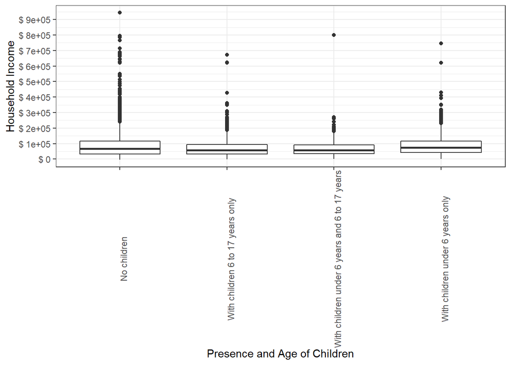

```r
ggplot(households, aes(x = HUPAC_label, y = HINCP)) +
  geom_boxplot() +
  theme_bw() +
  theme(axis.text.x = element_text(angle = 90)) +
  scale_x_discrete(name = "Presence and Age of Children") +
  scale_y_continuous(name = "Household Income",
                     breaks = seq(0, 1000000, by = 100000),
                     labels = paste("$",
                                    prettyNum(seq(0, 1000000, by = 100000),
                                              big.mark = ",")))
```

There appears to be a significant relationship between household income and the presence and age of children in the household with a P value near 0, though when it is plotted there is only a small difference in average income across the groups.

```r
anova_GRNTPHUPAC <- aov(GRNTP ~ HUPAC_label, data = households)

summary(anova_GRNTPHUPAC)
```

```
##                Df   Sum Sq Mean Sq F value   Pr(>F)
## HUPAC_label     3 2.70e+07 8999168   13.13 1.46e-08 ***
## Residuals   16494 1.13e+10  685264
## ---
## Signif. codes:  0 '***' 0.001 '**' 0.01 '*' 0.05 '.' 0.1 ' ' 1
```

```r
differences_GRNTPHUPAC <- TukeyHSD(anova_GRNTPHUPAC)

as_tibble(cbind(pair = row.names(differences_GRNTPHUPAC$HUPAC_label),
                differences_GRNTPHUPAC$HUPAC_label))
```

```
## # A tibble: 6 x 5
##   pair                               diff       lwr       upr       `p adj`
##   <chr>                              <chr>      <chr>     <chr>     <chr>
## 1 With children 6 to 17 years only-~ -36.57006~ -79.0270~ 5.886943~ 0.119686051~
## 2 With children under 6 years and 6~ -45.44608~ -103.361~ 12.46918~ 0.181985627~
## 3 With children under 6 years only-~ 107.70950~ 51.34962~ 164.0693~ 5.501306186~
## 4 With children under 6 years and 6~ -8.876014~ -74.0235~ 56.27155~ 0.985281478~
## 5 With children under 6 years only-~ 144.27957~ 80.51074~ 208.0484~ 6.418977938~
## 6 With children under 6 years only-~ 153.15559~ 78.20198~ 228.1091~ 9.476589160~
```

[figure not shown]

```r
ggplot(households, aes(x = HUPAC_label, y = GRNTP)) +
  geom_boxplot() +
  theme_bw() +
  theme(axis.text.x = element_text(angle = 90)) +
  scale_x_discrete(name = "Access to Internet") +
  scale_y_continuous(name = "Gross Monthly Rent",
                     breaks = seq(0, 6000, by = 1000),
                     labels = paste("$",
                                    prettyNum(seq(0, 6000, by = 1000),
                                              big.mark = ",")))
```

There appears to be a significant relationship between rent and presence/age of children according to the P value. The difference in median rent does not appear to be pronounced in the box plot, but the interquartile range does appear to vary notably by presence of children.

```r
anova_GRPIPHUPAC <- aov(GRPIP ~ HUPAC_label, data = households)

summary(anova_GRPIPHUPAC)
```

```
##                Df  Sum Sq Mean Sq F value Pr(>F)
## HUPAC_label     3   72023   24008    65.6 <2e-16 ***
## Residuals   16494 6036541     366
## ---
## Signif. codes:  0 '***' 0.001 '**' 0.01 '*' 0.05 '.' 0.1 ' ' 1
```

```r
differences_GRPIPHUPAC <- TukeyHSD(anova_GRPIPHUPAC)

as_tibble(cbind(pair = row.names(differences_GRPIPHUPAC$HUPAC_label),
                differences_GRPIPHUPAC$HUPAC_label))
```

```
## # A tibble: 6 x 5
##   pair                              diff       lwr        upr        `p adj`
##   <chr>                             <chr>      <chr>      <chr>      <chr>
## 1 With children 6 to 17 years only~ 4.5111900~ 3.5300033~ 5.4923767~ 2.67660555~
## 2 With children under 6 years and ~ 4.5388112~ 3.2003823~ 5.8772400~ 2.67660882~
## 3 With children under 6 years only~ -0.298867~ -1.601351~ 1.0036158~ 0.93527611~
## 4 With children under 6 years and ~ 0.0276211~ -1.477947~ 1.5331894~ 0.99996241~
## 5 With children under 6 years only~ -4.810057~ -6.283763~ -3.336352~ 2.67660970~
## 6 With children under 6 years only~ -4.837679~ -6.569866~ -3.105491~ 2.67705886~
```

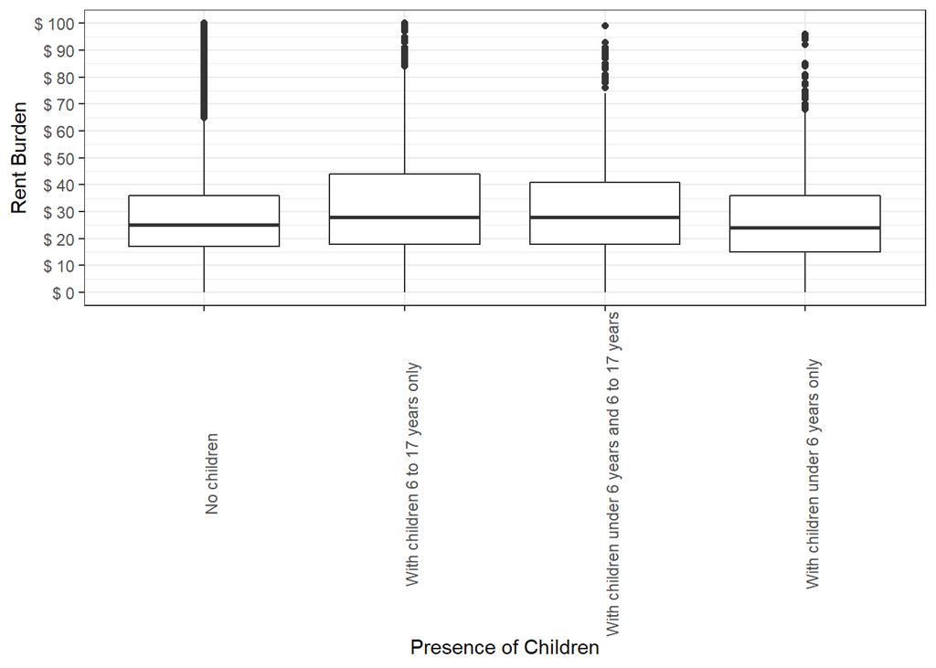

```r
ggplot(households, aes(x = HUPAC_label, y = GRPIP)) +
  geom_boxplot() +
  theme_bw() +
  theme(axis.text.x = element_text(angle = 90)) +
  scale_x_discrete(name = "Presence of Children") +
  scale_y_continuous(name = "Rent Burden",
                     breaks = seq(0, 100, by = 10),
                     labels = paste("$",
                                    prettyNum(seq(0, 100, by = 10),
                                              big.mark = ",")))
```

Again, there appears to be a statistically significant relationship between rent burden and presence of children with a near 0 P-value. It seems that the presence of children over 6 may be correlated to a somewhat higher rent burden than for those without children or with children under 6.

```r
chi_sq <- chisq.test(households$HUPAC_label, households$LNGI_label ==
                       "At least one person in the household 14 and over speaks English only or speaks English 'very well'")

chi_sq
```

```
##
##  Pearson's Chi-squared test
##
## data:  households$HUPAC_label and households$LNGI_label == "At least one person in the household 14 and over speaks English only or speaks English 'very well'"
## X-squared = 148.48, df = 3, p-value < 2.2e-16
```

```r
chi_sq$observed
```

```
##
## households$HUPAC_label                          FALSE TRUE
##   No children                                     799 9115
##   With children 6 to 17 years only                396 2964
##   With children under 6 years and 6 to 17 years   271 1290
##   With children under 6 years only                174 1489
```

```r
chi_sq$expected
```

```
##
## households$HUPAC_label                             FALSE     TRUE
##   No children                                   985.5110 8928.489
##   With children 6 to 17 years only              334.0041 3025.996
##   With children under 6 years and 6 to 17 years 155.1727 1405.827
##   With children under 6 years only              165.3122 1497.688
```

The P-value indicates that there is likely a significant relationship between presence of children and English-speaking ability.

```r
chi_sq2 <- chisq.test(households$ACCESS_label, households$LNGI_label ==
                       "At least one person in the household 14 and over speaks English only or speaks English 'very well'")

chi_sq2
```

```
##
##  Pearson's Chi-squared test
##
## data:  households$ACCESS_label and households$LNGI_label == "At least one person in the household 14 and over speaks English only or speaks English 'very well'"
## X-squared = 236.73, df = 2, p-value < 2.2e-16
```

```r
chi_sq2$observed
```

```
##
## households$ACCESS_label                                                 FALSE
##   No access to the Internet at this house, apartment, or mobile home      316
##   Yes, by paying a cell phone company or Internet service provider       1283
##   Yes, without paying a cell phone company or Internet service provider    41
##
## households$ACCESS_label                                                  TRUE
##   No access to the Internet at this house, apartment, or mobile home     1165
##   Yes, by paying a cell phone company or Internet service provider      13325
##   Yes, without paying a cell phone company or Internet service provider   368
```

```r
chi_sq2$expected
```

```
##
## households$ACCESS_label                                                      FALSE
##   No access to the Internet at this house, apartment, or mobile home     147.22027
##   Yes, by paying a cell phone company or Internet service provider      1452.12268
##   Yes, without paying a cell phone company or Internet service provider   40.65705
##
## households$ACCESS_label                                                      TRUE
##   No access to the Internet at this house, apartment, or mobile home     1333.780
##   Yes, by paying a cell phone company or Internet service provider      13155.877
##   Yes, without paying a cell phone company or Internet service provider   368.343
```

```r
chi_sq3 <- chisq.test(households$ACCESS_label, households$HUPAC_label ==
                       "No children")

chi_sq3
```

```
##
##  Pearson's Chi-squared test
##
## data:  households$ACCESS_label and households$HUPAC_label == "No children"
## X-squared = 214.92, df = 2, p-value < 2.2e-16
```

```r
chi_sq3$observed
```

```
##
## households$ACCESS_label                                                 FALSE
##   No access to the Internet at this house, apartment, or mobile home      333
##   Yes, by paying a cell phone company or Internet service provider       6110
##   Yes, without paying a cell phone company or Internet service provider   141
##
## households$ACCESS_label                                                 TRUE
##   No access to the Internet at this house, apartment, or mobile home    1148
##   Yes, by paying a cell phone company or Internet service provider      8498
##   Yes, without paying a cell phone company or Internet service provider  268
```

```r
chi_sq3$expected
```

```
##
## households$ACCESS_label                                                     FALSE
##   No access to the Internet at this house, apartment, or mobile home     591.0355
##   Yes, by paying a cell phone company or Internet service provider      5829.7413
##   Yes, without paying a cell phone company or Internet service provider  163.2232
##
## households$ACCESS_label                                                      TRUE
##   No access to the Internet at this house, apartment, or mobile home     889.9645
##   Yes, by paying a cell phone company or Internet service provider      8778.2587
##   Yes, without paying a cell phone company or Internet service provider  245.7768
```

The P-value indicates that there is likely a significant relationship between presence of children and internet access. This is somehwat apparent in the differences in observed and expected chi-square test results.